# Performance Evaluation

Sarah Boctor

Wednesday, May 13, 2015

[output not shown]

[output not shown]

### Funds used in creating the portfolio

change the color palette to get all assets

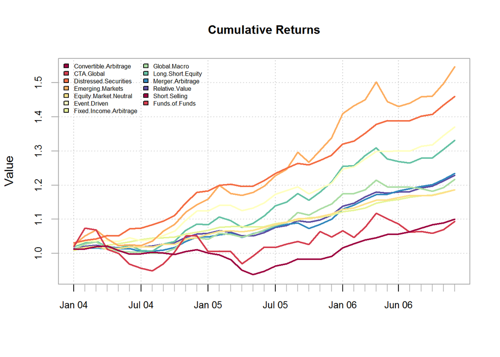

```r
par(cex=0.86)
par(mfrow=c(1,1))

chart.CumReturns(Managers[,1:13], main="Cumulative Returns",
                 wealth.index=TRUE,col= brewer.pal(13, "Spectral"), legend.loc=NULL)
par(cex=.65)
legend("topleft", legend=manager.names,text.width=5.7 , pt.cex=2,inset=0, fill= brewer.pal(13, "Spectral"), bty="n", ncol=2, cex=0.8)
```

```r
par(cex=.8)
```

## Create Optimal Portfolio

- we will assume quarterly rebalancing, and will add a weight limit for most funds of 30% long or short, and for 2 risky funds a lower limit of 5% long/short . Also the portfolio will have a position limit of 10 maximum positive positions, and 2 negative positions.
- The Portfolio will satisfy a maximum percent ES(Expected Shortfall) objective of 0.5 and an overall monthly mean return of 0.001

[output not shown]

```
## PortfolioAnalytics Optimization with Rebalancing
##
## Call:
## optimize.portfolio.rebalancing(R = managers1, portfolio = port,
##     optimize_method = "random", search_size = 5000, trace = TRUE,
##     rebalance_on = "quarters", training_period = 10)
##
## Number of rebalancing dates:  9
## First rebalance date:
## [1] "2004-12-31 EST"
## Last rebalance date:
## [1] "2006-12-31 EST"
##
## Annualized Portfolio Rebalancing Return:
## [1] 0.09531
##
## Annualized Portfolio Standard Deviation:
## [1] 0.03521
```

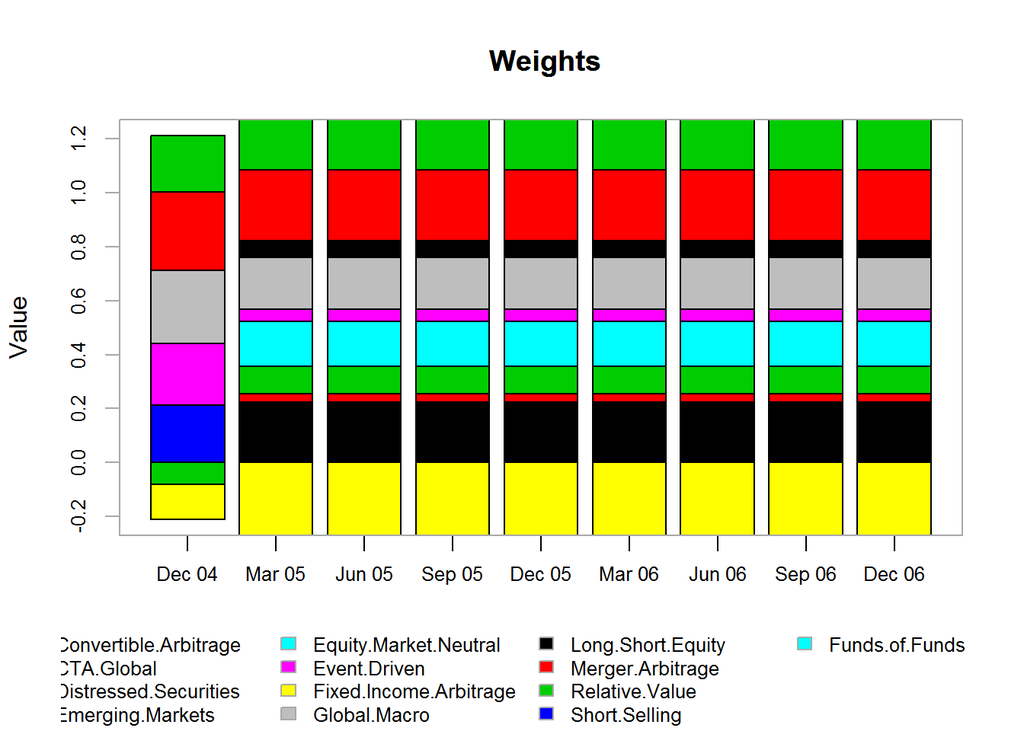

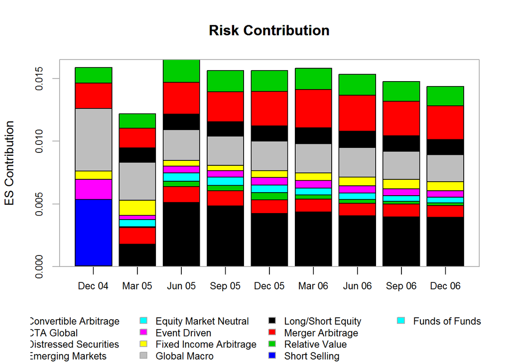

## Create an Efficient Frontier and Chart the Weights

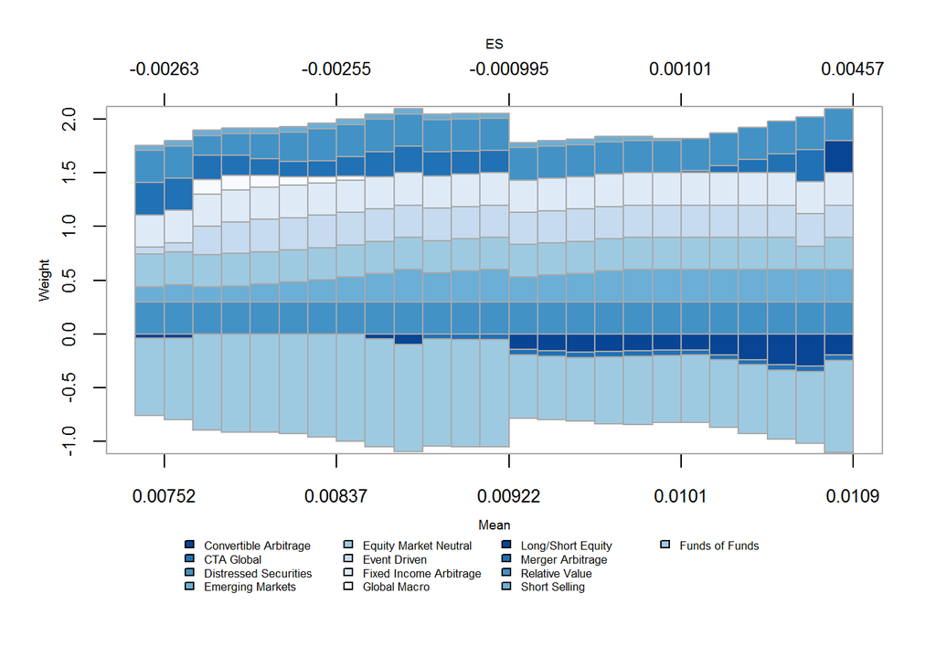

```r
HP=Return.portfolio(R=managers1,weights=weights,geometric=TRUE,rebalance_on="quarters",value=1,verbose=FALSE)
colnames(HP)="Portfolio"
data(managers)
sp500=(managers["2004::2006",8])
HAM=merge(HP,sp500)


table.AnnualizedReturns(HAM,scale=12,Rf=0.0009,digits=3)
```

```
##                              Portfolio SP500.TR
## Annualized Return                0.068    0.104
## Annualized Std Dev               0.043    0.069
## Annualized Sharpe (Rf=1.08%)     1.306    1.339
```

# Calendar Returns

```r
table.CalendarReturns(HAM,digits=1,as.perc=TRUE)
```

```
##      Jan  Feb  Mar  Apr  May  Jun  Jul Aug  Sep Oct Nov  Dec Portfolio
## 2004 1.0  0.7 -1.7 -1.0 -0.4 -0.7 -0.1 1.0  0.4 2.2 0.9 -0.2       2.0
## 2005 1.2 -1.1 -2.0  0.5  1.5  1.9  0.8 2.2 -1.4 1.5 1.8  3.4      10.7
## 2006 0.6  1.6  1.6 -1.6 -0.1  0.1  0.6 0.2  1.3 1.8 1.6  0.0       7.8
##      SP500.TR
## 2004     10.9
## 2005      4.9
## 2006     15.8
```

# Trailing Periods Return

```r
results=table.TrailingPeriods(HAM,periods= c( 6, 12, 18, 24, 30))

require("Hmisc")
```

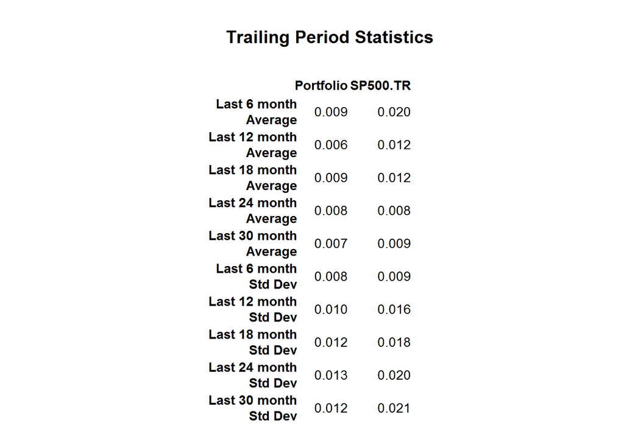

```r
textplot(format.df(results, na.blank=TRUE, numeric.dollar=FALSE,
                   cdec=rep(3,dim(result)[2])), rmar = 0.01, cmar = 0.5,
         max.cex=.9, halign = "center", valign = "bottom", row.valign="center",
         wrap.rownames=15, wrap.colnames=3, mar = c(0,0,3,0)+0.1)
title(main="Trailing Period Statistics")
```

# Rolling Performance

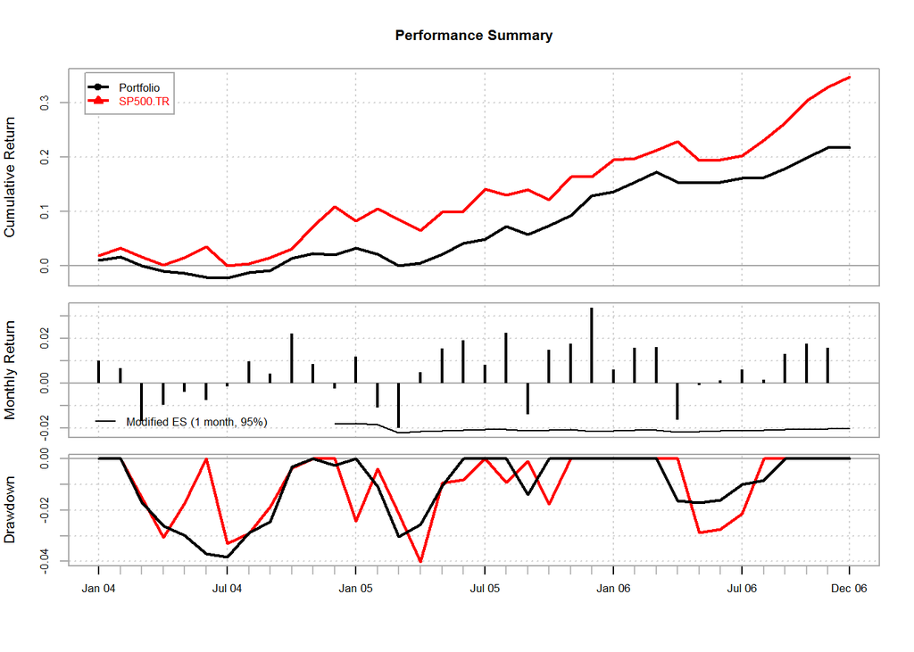

```r
charts.PerformanceSummary(HAM,Rf=0.001,main="Performance Summary", methods = "ModifiedES",legend.loc="topleft")
```

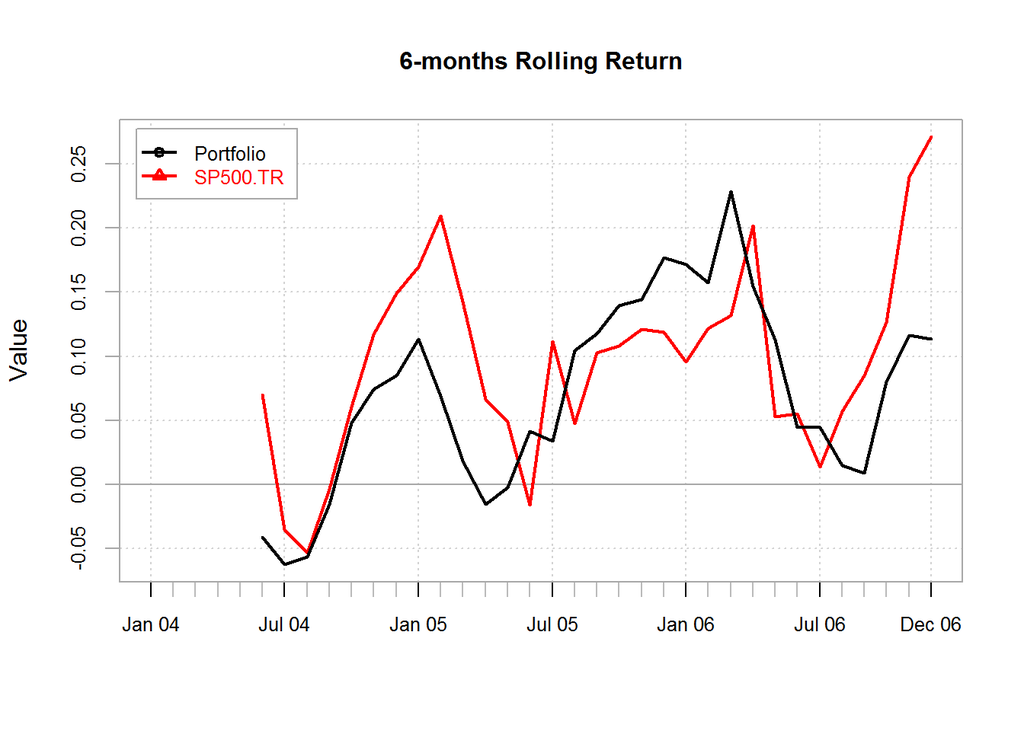

```r
chart.RollingPerformance(HAM, width = 6,FUN = "Return.annualized", legend.loc="topleft",
                         ylim = NULL, main = "6-months Rolling Return" , fill = NA)
```

# Relative Performance

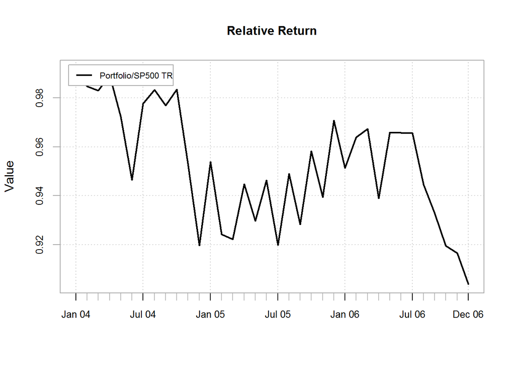

```r
chart.RelativePerformance(HP,sp500,main = "Relative Return",legend.loc="topleft",
                          xaxis = TRUE)
```

# Outperformance and Underperformance

```r
table.UpDownRatios(HP,sp500,digits=2)
```

```
##                       Up Capture Down Capture Up Number Down Number
## Portfolio to SP500 TR        0.4        -0.03      0.74        0.56
##                       Up Percent Down Percent
## Portfolio to SP500 TR       0.22         0.78
```

```r
table.ProbOutPerformance(HP,sp500,period_lengths=c(1, 3, 6, 9, 12, 18, 36))
```

```
##   period_lengths Portfolio SP500 TR total periods
## 1              1        13       23            36
## 2              3        12       22            34
## 3              6        11       20            31
## 4              9        12       16            28
## 5             12         7       18            25
## 6             18         6       13            19
## 7             36         0        1             1
##   prob_Portfolio_outperformance prob_SP500 TR_outperformance
## 1                        0.3611                       0.6389
## 2                        0.3529                       0.6471
## 3                        0.3548                       0.6452
## 4                        0.4286                       0.5714
## 5                        0.2800                       0.7200
## 6                        0.3158                       0.6842
## 7                        0.0000                       1.0000
```

# Upside and Downside Frequency

```r
a=UpsideFrequency(HAM,MAR=0.008)
b=DownsideFrequency(HAM,MAR=0.008)

c=rbind(a,b)
c
```

```
##                                   Portfolio SP500.TR
## Upside Frequency (MAR = 0.008%)      0.4722   0.5833
## Downside Frequency (MAR = 0.008%)    0.5278   0.4167
```

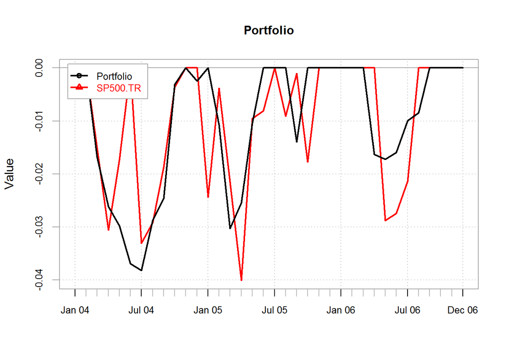

```r
chart.Drawdown(HAM,legend.loc="topleft")
```

## Risk Analysis

[figure not shown]

```r
Cash= (managers["2004::3006",10])
HAM2=cbind(HAM,Style["2004::2006"])

par(cex=.65)
charts.RollingPerformance(HAM2[,1:4],width=6,
                          Rf=Cash,
                          colorset=tim8equal,
                          main="Rolling 12-Month Performance",
                          legend.loc="bottomleft", box.col=NULL)
```

```r
                          par(cex=.8)
table.DownsideRisk(HAM,scale = 12,Rf = Cash,MAR=0.0085, digits = 3)
```

```
##                                Portfolio SP500.TR
## Semi Deviation                     0.009    0.015
## Gain Deviation                     0.008    0.012
## Loss Deviation                     0.007    0.007
## Downside Deviation (MAR=10.2%)     0.011    0.015
## Downside Deviation (Rf=3.03%)      0.007    0.011
## Downside Deviation (0%)            0.006    0.011
## Maximum Drawdown                   0.038    0.040
## Historical VaR (95%)              -0.016   -0.025
## Historical ES (95%)               -0.018   -0.031
## Modified VaR (95%)                -0.016   -0.026
## Modified ES (95%)                 -0.020   -0.032
```

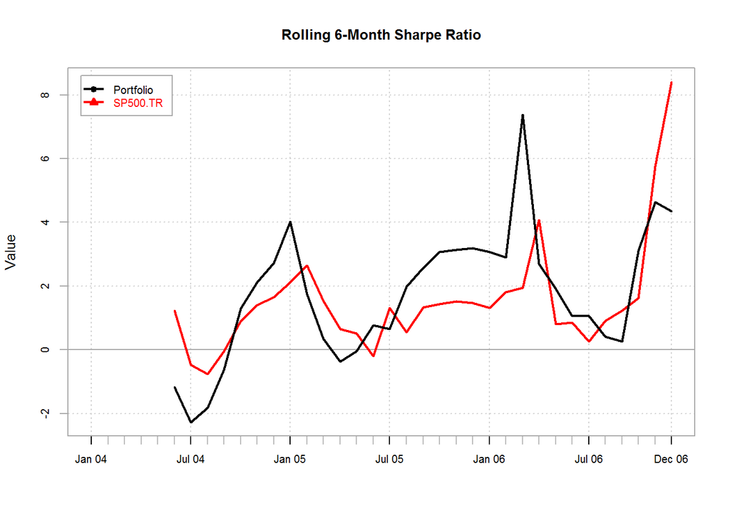

```r
chart.RollingPerformance(HAM,width = 6,FUN = "SharpeRatio.annualized",main = "Rolling 6-Month Sharpe Ratio",legend.loc="topleft")
```

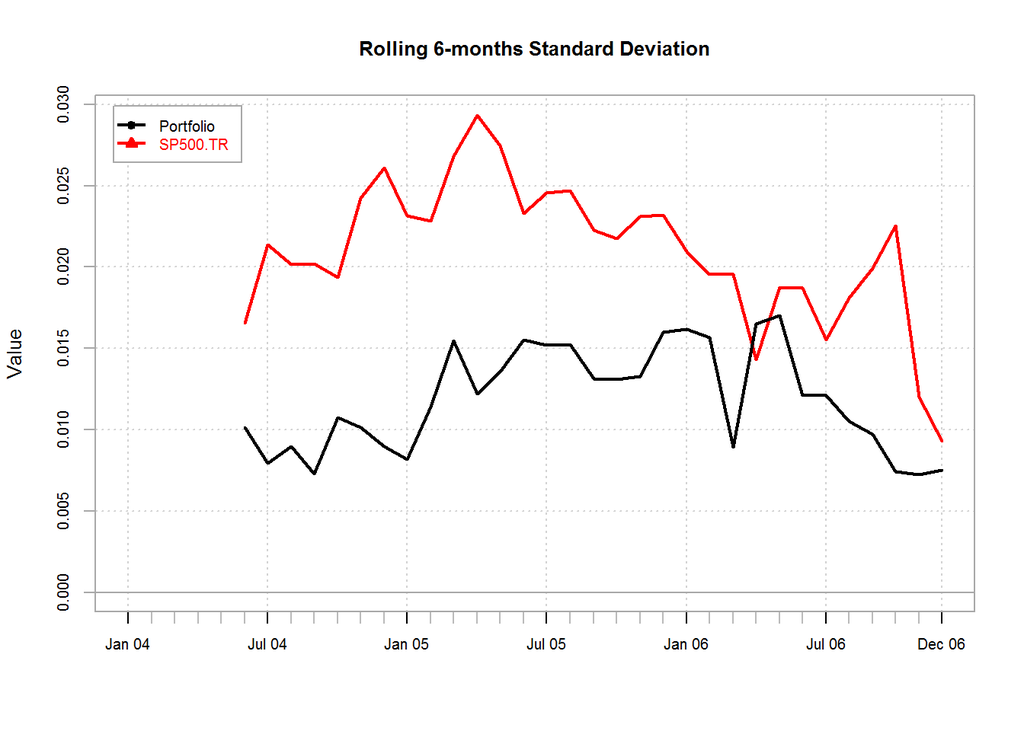

```r
chart.RollingPerformance(HAM,width = 6,FUN = "StdDev",main = "Rolling 6-months Standard Deviation",legend.loc="topleft")
```

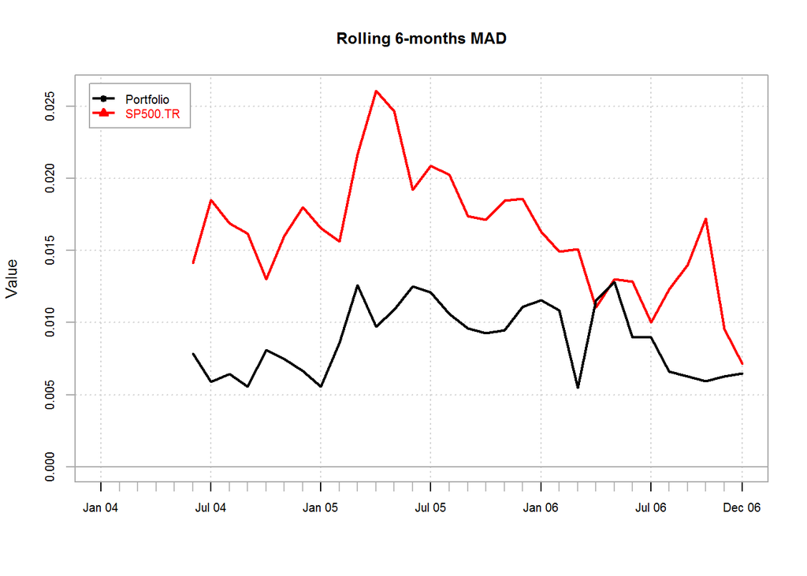

```r
chart.RollingPerformance(HAM,width = 6,FUN = "MeanAbsoluteDeviation",main = "Rolling 6-months MAD",legend.loc="topleft")
```

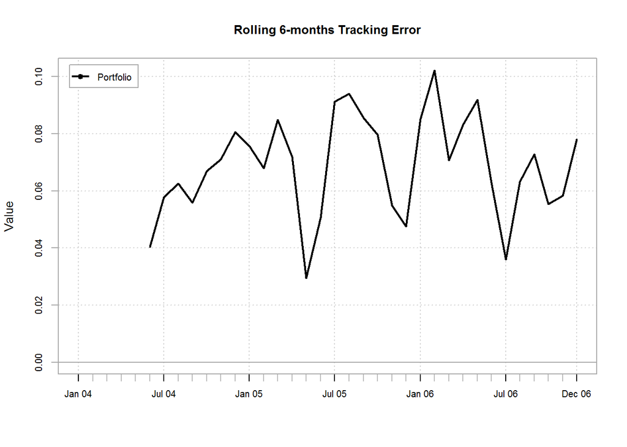

```r
chart.RollingPerformance(HP,width = 6,FUN = "TrackingError",main = "Rolling 6-months Tracking Error",Rb=sp500,legend.loc="topleft")
```

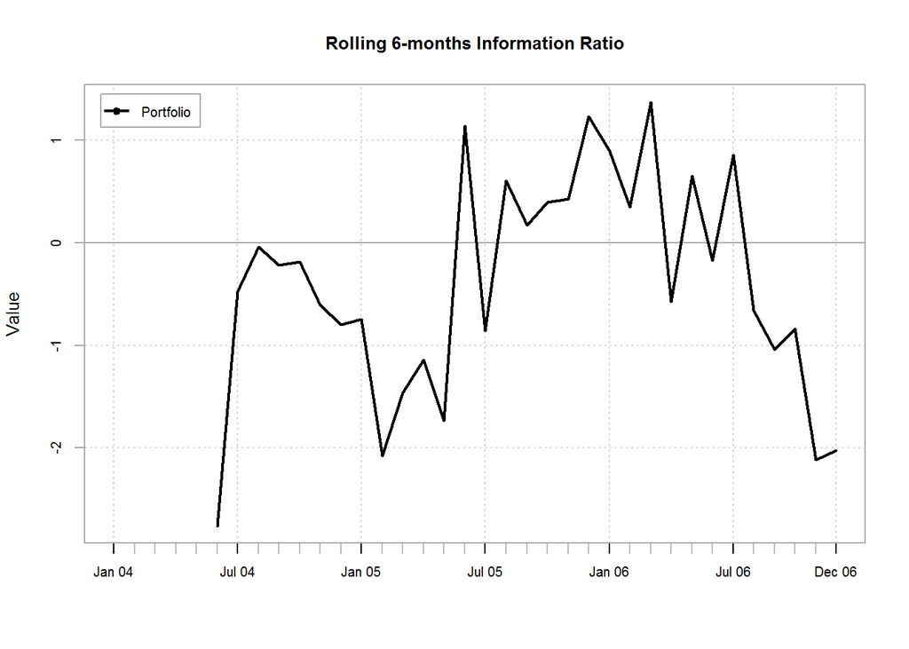

```r
chart.RollingPerformance(HP,width = 6,FUN = "InformationRatio",main = "Rolling 6-months Information Ratio",Rb=sp500,legend.loc="topleft")
```

## Style Analysis

- Performing Sharpe Style Analysis on the Hypothetical Composite Portfolio by first conducting the style analysis on the component funds

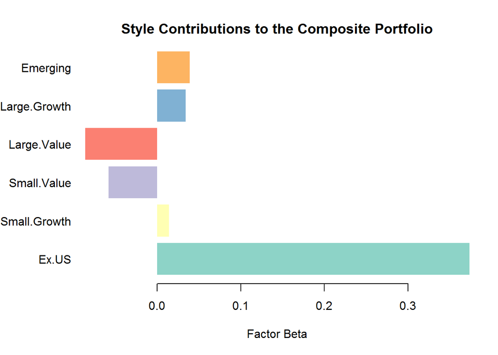

```r
# initialize list object to hold regression objects
reg.list = list()
# initialize matrices and vectors to hold estimated betas,
# residual variances, and R-square values from
# fitted factor models
Betas = matrix(0, length(manager.names), length(index.names))
colnames(Betas) = index.names
rownames(Betas) = manager.names
Alphas = ResidVars = R2values = rep(0, length(manager.names))
names(Alphas) = names(ResidVars) = names(R2values) = manager.names

# loop over all assets and estimate time series regression
for (i in manager.names) {
    reg.df = na.omit(Managers.df[, c(i, index.names)])
    fm.formula = as.formula(paste(i,"~", ".", sep=" "))
    fm.fit = lm(fm.formula, data=reg.df)
    fm.summary = summary(fm.fit)
    reg.list[[i]] = fm.fit
    Alphas[i] = coef(fm.fit)[1]
    Betas[i, ] = coef(fm.fit)[-1]
    ResidVars[i] = fm.summary$sigma^2
    R2values[i] =  fm.summary$r.squared
}
reg.results = cbind(Betas, sqrt(ResidVars), R2values)
colnames(reg.results)[7] = "ResidSD"

# risk factor sample covariance matrix
cov.factors = var(Managers.df[, index.names])
# FM covariance matrix
cov.fm = Betas%*%cov.factors%*%t(Betas) + diag(ResidVars)
# FM correlation matrix
cor.fm = cov2cor(cov.fm)
# plot correlations using plotcorr() from ellipse package
rownames(cor.fm) = colnames(cor.fm)
ord <- order(cor.fm[1,])

# compute mu.fm and sigma.fm for all assets. Set alpha = 0 for mu.fm

mu.factors = colMeans(Managers[, index.names])
mu.fm = Betas%*%mu.factors
sigma.fm = sqrt(diag(cov.fm))

# portfolio factor model
#

# equally weighted portfolio of 6 hedge funds
w.vec =as.numeric(weights)

# portfolio returns
r.p = as.matrix(HP)

r.p.zoo = zoo(HP, as.yearmon(rownames(HP)))


# portfolio factor model
alpha.p = as.numeric(crossprod(Alphas,w.vec))
beta.p = t(Betas)%*%w.vec
var.p.systematic = t(beta.p)%*%cov.factors%*%beta.p
var.p.resid = t(w.vec)%*%diag(ResidVars)%*%w.vec
var.fm.p = var.p.systematic + var.p.resid
var.fm.p = as.numeric(var.fm.p)
r.square.p = as.numeric(var.p.systematic/var.fm.p)
fm.p = c(alpha.p, beta.p, sqrt(var.fm.p), r.square.p)
names(fm.p) = c("intercept", index.names, "sd", "r-squared")

fm.resid = rep(0, nrow(HP))
smpl = rownames(HP)
for (i in manager.names) {
    reg.resid = residuals(reg.list[[i]])
    fm.resid = fm.resid + w.vec[i]*reg.resid[smpl]
}

fm=c(beta.p)
names(fm)=index.names

par(oma = c(1, 1, 1, 1))  # Outside margins: b, l, t, r
par(mar = c(4, 5, 2, 1))  # Sets plot margins
barplot(fm, horiz  = TRUE,
        las    = 1,  # Orientation of axis labels
        col    = brewer.pal(12, "Set3"),
        border = NA,  # No borders on bars
        main   = "Style Contributions to the Composite Portfolio",
        xlab   = "Factor Beta")
```

## Factor Risk Composition

```r
mu.fm.p = crossprod(beta.p, mu.factors)
sd.fm.p = sqrt(var.fm.p)

# normalVaR.r
##
## Normal VaR functions for portfolio VaR report
##

normalVaR <- function(mu, sigma, tail.prob = 0.01, invert=FALSE) {
## compute normal VaR for collection of assets given mean and sd vector
## inputs:
## mu         n x 1 vector of expected returns
## sigma      n x 1 vector of standard deviations
## tail.prob  scalar tail probability
## invert     logical. If TRUE report VaR as positive number
## output:
## VaR        n x 1 vector of left tail return quantiles
## References:
## Jorian (2007) pg 111.
  mu = as.matrix(mu)
  sigma = as.matrix(sigma)
  if ( nrow(mu) != nrow(sigma) )
    stop("mu and sigma must have same number of elements")
  if ( tail.prob < 0 || tail.prob > 1)
    stop("tail.prob must be between 0 and 1")
  VaR = mu + sigma*qnorm(tail.prob)
  if (invert) {
    VaR = -VaR
  }
  return(VaR)
}

# normalES.r
normalES <- function(mu, sigma, tail.prob = 0.01, invert=FALSE) {
## compute normal ES for collection of assets given mean and sd vector
## inputs:
## mu       n x 1 vector of expected returns
## sigma    n x 1 vector of standard deviations
## tail.prob  scalar tail probability
## invert   logical. If TRUE, return ES as positive number
## output:
## ES      n x 1 vector of left tail average returns reported as a positive number
  mu = as.matrix(mu)
  sigma = as.matrix(sigma)
  if ( nrow(mu) != nrow(sigma) )
    stop("mu and sigma must have same number of elements")
  if ( tail.prob < 0 || tail.prob > 1)
    stop("tail.prob must be between 0 and 1")
  ES = mu - sigma*dnorm(qnorm(tail.prob))/tail.prob
  if(invert) {
   ES = -ES
  }
  return(ES)
}
```

# Portfolio Tail Risk Measures

# Normal VaR

```r
VaR(HP, p=0.95, method="gaussian")
```

```
##     Portfolio
## VaR  -0.01466
```

```r
VaR(HP, p=0.99, method="gaussian")
```

```
##     Portfolio
## VaR  -0.02304
```

# Factor-Based Normal VaR

```r
normalVaR(mu.fm.p, sd.fm.p, tail.prob=0.05)
```

```
##          [,1]
## [1,] -0.01457
```

```r
normalVaR(mu.fm.p, sd.fm.p, tail.prob=0.01)
```

```
##          [,1]
## [1,] -0.02246
```

# Cornish-Fisher (modified VaR)

```r
VaR(HP, p=0.95, method="modified")
```

```
##     Portfolio
## VaR   -0.0155
```

```r
VaR(HP, p=0.99, method="modified")
```

```
##     Portfolio
## VaR  -0.02348
```

# Historical VaR

```r
VaR(HP, p=0.95, method="historical")
```

```
##     Portfolio
## VaR  -0.01643
```

```r
VaR(HP, p=0.99, method="historical")
```

```
##     Portfolio
## VaR  -0.01874
```

# Normal ES

```r
ES(HP, p=0.95, method="gaussian")
```

```
##    Portfolio
## ES   -0.0198
```

```r
ES(HP, p=0.99, method="gaussian")
```

```
##    Portfolio
## ES  -0.02721
```

# Factor-Based Normal ES

```r
normalES(mu.fm.p, sd.fm.p, tail.prob=0.05)
```

```
##          [,1]
## [1,] -0.01941
```

```r
normalES(mu.fm.p, sd.fm.p, tail.prob=0.01)
```

```
##          [,1]
## [1,] -0.02639
```

# Modified ES

```r
ES(HP, p=0.95, method="modified")
```

```
##    Portfolio
## ES  -0.02002
```

```r
ES(HP, p=0.99, method="modified")
```

```
##    Portfolio
## ES  -0.02709
```

# Historical ES

```r
ES(HP, p=0.95, method="historical")
```

```
##    Portfolio
## ES   -0.0183
```

```r
ES(HP, p=0.99, method="historical")
```

```
##    Portfolio
## ES  -0.01977
```

## Portfolio Risk Decomposition:

1- Analyzing Risk Factors Contribution to the Risk of the Composite Portfolio

- in this case, the risk factors I used are the different investment styles. These can be easily replaced with macroeconomic factors, or industry fundamentals, etc..

# Risk Factor Contribution to Standard Deviation

```r
factorModelFactorEsDecomposition <- function(bootData, beta.vec, sig2.e, tail.prob = 0.01,
                                            method=c("average"),
                                            VaR.method=c("HS", "CornishFisher")) {
## Compute factor model factor ES decomposition based on Euler's theorem given historic
## or simulated data and factor model parameters.
## The partial derivative of ES wrt factor beta is computed
## as the expected factor return given fund return is less than or equal to its VaR
## VaR is compute either as the sample quantile or as an estimated quantile
## using the Cornish-Fisher expansion
## inputs:
## bootData   B x (k+2) matrix of bootstrap data. First column contains the fund returns,
##            second through k+1 columns contain factor returns, (k+2)nd column contain residuals
##            scaled to have variance 1.
## beta.vec   k x 1 vector of factor betas
## sig2.e           scalar, residual variance from factor model
## tail.prob  scalar tail probability
## method     character, method for computing marginal ES. Valid choices are
##            "average" for approximating E[Fj | R<=VaR]
## VaR.method character, method for computing VaR. Valid choices are "HS" for
##            historical simulation (empirical quantile); "CornishFisher" for
##            modified VaR based on Cornish-Fisher quantile estimate. Cornish-Fisher
##            computation is done with the VaR.CornishFisher in the PerformanceAnalytics
##            package
## output:
## A list with the following components:
## VaR.fm              scalar, bootstrap VaR value for fund reported as a positive number
## n.exceed            scalar, number of observations beyond VaR
## idx.exceed          n.exceed x 1 vector giving index values of exceedences
## ES.fm               scalar, bootstrap ES value for fund reported as a positive number
## mcES.fm             k+1 x 1 vector of factor marginal contributions to ES
## cES.fm              k+1 x 1 vector of factor component contributions to ES
## pcES.fm             k+1 x 1 vector of factor percent contributions to ES
## Remarks:
## The factor model has the form
## R(t) = beta'F(t) + e(t) = beta.star'F.star(t)
## where beta.star = (beta, sig.e)' and F.star(t) = (F(t)', z(t))'
## By Euler's theorem
## ES.fm = sum(cES.fm) = sum(beta.star*mcES.fm)
## References:
## 1. Hallerback (2003), "Decomposing Portfolio Value-at-Risk: A General Analysis",
##    The Journal of Risk 5/2.
## 2. Yamai and Yoshiba (2002). "Comparative Analyses of Expected Shortfall and
##    Value-at-Risk: Their Estimation Error, Decomposition, and Optimization
##    Bank of Japan.
## 3. Meucci (2007). "Risk Contributions from Generic User-Defined Factors," Risk.
  require(PerformanceAnalytics)
  VaR.method = VaR.method[1]
  bootData = as.matrix(bootData)
  ncol.bootData = ncol(bootData)
  if(is.matrix(beta.vec)) {
    beta.names = c(rownames(beta.vec), "residual")
  } else if(is.vector(beta.vec)) {
    beta.names = c(names(beta.vec), "residual")
  } else {
   stop("beta.vec is not an n x 1 matrix or a vector")
  }
#  beta.names = c(names(beta.vec), "residual")
    beta.star.vec = c(beta.vec, sqrt(sig2.e))
    names(beta.star.vec) = beta.names

  if (VaR.method == "HS") {
    VaR.fm = quantile(bootData[, 1], prob=tail.prob)
    idx = which(bootData[, 1] <= VaR.fm)
    ES.fm = -mean(bootData[idx, 1])
  } else {
    VaR.fm = -VaR.CornishFisher(bootData[, 1], p=(1-tail.prob))
    idx = which(bootData[, 1] <= pVaR)
    ES.fm = -mean(bootData[idx, 1])
  }
  ##
  ## compute marginal contribution to ES
  ##
  if (method == "average") {
  ## compute marginal ES as expected value of factor return given fund
  ## return is less than or equal to VaR
    mcES.fm = -as.matrix(colMeans(bootData[idx, -1]))
  } else {
    stop("invalid method")
  }

## compute correction factor so that sum of weighted marginal ES adds to portfolio ES
#cf = as.numeric( ES.fm / sum(mcES.fm*beta.star.vec) )
#mcES.fm = cf*mcES.fm
cES.fm = mcES.fm*beta.star.vec
pcES.fm = cES.fm/ES.fm
colnames(mcES.fm) = "MCES"
colnames(cES.fm) = "CES"
colnames(pcES.fm) = "PCES"
ans = list(VaR.fm = -VaR.fm,
           n.exceed = length(idx),
           idx.exceed = idx,
           ES.fm = ES.fm,
           mcES.fm = t(mcES.fm),
           cES.fm = t(cES.fm),
           pcES.fm = t(pcES.fm))
return(ans)
}
factorModelFactorSdDecomposition <- function(beta.vec, factor.cov, sig2.e) {
## Inputs:
## beta            k x 1 vector of factor betas with factor names in the rownames
## factor.cov        k x k factor excess return covariance matrix
## sig2.e              scalar, residual variance from factor model
## Output:
## A list with the following components:
## sd.fm              scalar, std dev based on factor model
## mcr.fm             k+1 x 1 vector of factor marginal contributions to risk (sd)
## cr.fm              k+1 x 1 vector of factor component contributions to risk (sd)
## pcr.fm             k+1 x 1 vector of factor percent contributions to risk (sd)
## Remarks:
## The factor model has the form
## R(t) = beta'F(t) + e(t) = beta.star'F.star(t)
## where beta.star = (beta, sig.e)' and F.star(t) = (F(t)', z(t))'
## By Euler's theorem
## sd.fm = sum(cr.fm) = sum(beta*mcr.fm)
  if(is.matrix(beta.vec)) {
    beta.names = c(rownames(beta.vec), "residual")
  } else if(is.vector(beta.vec)) {
    beta.names = c(names(beta.vec), "residual")
  } else {
   stop("beta.vec is not a matrix or a vector")
  }
  beta.vec = as.vector(beta.vec)
    beta.star.vec = c(beta.vec, sqrt(sig2.e))
    names(beta.star.vec) = beta.names
    factor.cov = as.matrix(factor.cov)
    k.star = length(beta.star.vec)
    k = k.star - 1
    factor.star.cov = diag(k.star)
    factor.star.cov[1:k, 1:k] = factor.cov

## compute factor model sd
  sd.fm = as.numeric(sqrt(t(beta.star.vec) %*% factor.star.cov %*% beta.star.vec))
## compute marginal and component contributions to sd
    mcr.fm = (factor.star.cov %*% beta.star.vec)/sd.fm
    cr.fm = mcr.fm * beta.star.vec
    pcr.fm = cr.fm/sd.fm
    rownames(mcr.fm) <- rownames(cr.fm) <- rownames(pcr.fm) <- beta.names
    colnames(mcr.fm) = "MCR"
    colnames(cr.fm) = "CR"
    colnames(pcr.fm) = "PCR"
## return results
    ans = list(sd.fm = sd.fm,
             mcr.fm = t(mcr.fm),
             cr.fm = t(cr.fm),
             pcr.fm = t(pcr.fm))
    return(ans)
}
portfolioEsDecomposition <- function(bootData, w, delta.w = 0.001, tail.prob = 0.01,
                                     method=c("derivative", "average"),
                                     VaR.method=c("HS", "CornishFisher")) {
## Compute portfolio ES decomposition given historical or simulated data and portfolio weights.
## Marginal ES is computed either as the numerical derivative of ES wrt portfolio weight or
## as the expected fund return given portfolio return is less than or equal to portfolio VaR
## VaR is compute either as the sample quantile or as an estimated quantile
## using the Cornish-Fisher expansion
## inputs:
## bootData   B x n matrix of B bootstrap returns on assets in portfolio.
## w          n x 1 vector of portfolio weights
## delta.w    scalar, change in portfolio weight for computing numerical derivative
## tail.prob  scalar tail probability
## method     character, method for computing marginal ES. Valid choices are
##            "derivative" for numerical computation of the derivative of portfolio
##            ES wrt fund portfolio weight; "average" for approximating E[Ri | Rp<=VaR]
## VaR.method character, method for computing VaR. Valid choices are "HS" for
##            historical simulation (empirical quantile); "CornishFisher" for
##            modified VaR based on Cornish-Fisher quantile estimate. Cornish-Fisher
##            computation is done with the VaR.CornishFisher in the PerformanceAnalytics
##            package
## output:
## pVaR       scalar, portfolio VaR reported as a positive number
## pES        scalar, portfolio ES reported as a positive number
## n.exceed   scalar, number of VaR exceedences
## idx.exceed n.exceed x 1 vector of exceedence indices
## mES        1 x n matrix of marginal ES values for each fund
## cES        1 x n matrix of component ES values
## pcES       1 x n matrix of percent contributions to portfolio ES values
## References:
## 1. Hallerback (2003), "Decomposing Portfolio Value-at-Risk: A General Analysis",
##    The Journal of Risk 5/2.
## 2. Yamai and Yoshiba (2002). "Comparative Analyses of Expected Shortfall and
##    Value-at-Risk: Their Estimation Error, Decomposition, and Optimization
##    Bank of Japan.
  require(PerformanceAnalytics)
  method = method[1]
  VaR.method = VaR.method[1]
  bootData = as.matrix(bootData)
  w = as.matrix(w)
  if ( ncol(bootData) != nrow(w) )
    stop("Columns of bootData and rows of w do not match")
  if ( tail.prob < 0 || tail.prob > 1)
    stop("tail.prob must be between 0 and 1")
```

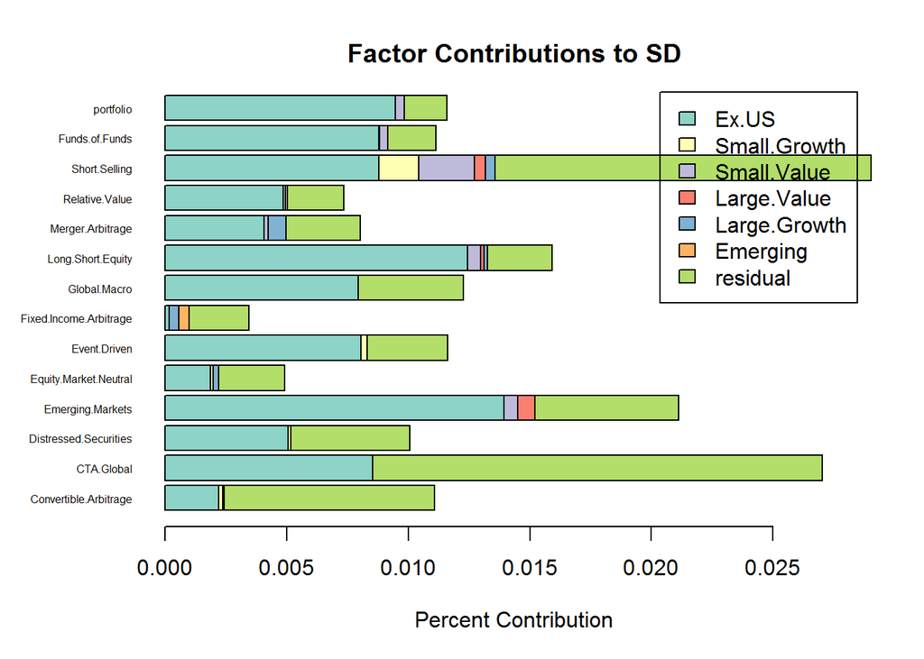

```r
  n.w = nrow(w)

  ## portfolio VaR and ES with all assets
  r.p = bootData %*% w
  if (VaR.method == "HS") {
    pVaR = quantile(r.p, prob=tail.prob)
    idx = which(r.p <= pVaR)
    pES = -mean(r.p[idx])
  } else {
    pVaR = -VaR.CornishFisher(r.p, p=(1-tail.prob))
    idx = which(r.p <= pVaR)
    pES = -mean(r.p[idx])
  }
  ##
  ## compute marginal ES
  ##
  if (method=="derivative") {
  ## compute marginal ES as derivative wrt portfolio weight
    temp.w = w
    mES = matrix(0, n.w, 1)
    for (i in 1:n.w) {
    ## increment weight for asset i by delta.w
      temp.w[i,1] = w[i,1] + delta.w
      temp.r.p = bootData %*% temp.w
      if (VaR.method == "HS") {
        pVaR.new = quantile(temp.r.p, prob=tail.prob)
        idx = which(temp.r.p <= pVaR.new)
        pES.new = -mean(temp.r.p[idx])
      } else {
        pVaR.new = -VaR.CornishFisher(temp.r.p, p=(1-tail.prob))
        idx = which(temp.r.p <= pVaR.new)
        pES.new = -mean(temp.r.p[idx])
      }
      mES[i,1] = (pES.new - pES)/delta.w
    ## reset weight
      temp.w = w
    }
  } else {
  ## compute marginal ES as expected value of fund return given portfolio
  ## return is less than or equal to portfolio VaR
    if (ncol(bootData) > 1) {
      mES = -as.matrix(colMeans(bootData[idx,]))
    } else {
      mES = -as.matrix(mean(bootData[idx, ]))
    }
  }
## compute correction factor so that sum of weighted marginal ES adds to portfolio VaR
cf = as.numeric( pES / sum(mES*w) )
## mES = cf*mES

## compute component and percent ES
cES = mES * w
pcES = cES/pES
rownames(mES) = colnames(bootData)
colnames(mES) = "MCES"
colnames(cES) = "CES"
colnames(pcES) = "PCES"

ans = list(VaR.fm = -pVaR,
           ES.fm = pES,
           n.exceed = length(idx),
           idx.exceed = idx,
           MCES = t(mES),
           CES = t(cES),
           PCES = t(pcES))
return(ans)
}
portfolioSdDecomposition <- function(w.vec, cov.assets) {
## Inputs:
## w.vec         n x 1 vector of portfolio weights
## cov.assets        n x n asset covariance matrix
## Output:
## A list with the following components:
## sd.p          scalar, portfolio sd
## mcsd.p        1 x n vector, marginal contributions to portfolio sd
## csd.p         1 x n vector, contributions to portfolio sd
## pcsd.p        1 x n vector, percent contribution to portfolio sd

 if (any(diag(chol(cov.assets)) == 0))
    warning("Asset covariance matrix is not positive definite")
 ## compute portfolio level variance
 var.p = as.numeric(t(w.vec) %*% cov.assets %*% w.vec)
 sd.p = sqrt(var.p)
 ## compute marginal, component and percentage contributions to risk
 mcsd.p = (cov.assets %*% w.vec)/sd.p
 csd.p = w.vec*mcsd.p
 pcsd.p = csd.p/sd.p
 colnames(mcsd.p) = "MCSD"
 colnames(csd.p) = "CSD"
 colnames(pcsd.p) = "PCSD"
 ## return results
 ans = list(sd.p=sd.p,
            mcsd.p=t(mcsd.p),
            csd.p=t(csd.p),
            pcsd.p=t(pcsd.p))
 return(ans)
}

factor.sd.decomp.list = list()
for (i in manager.names) {
    factor.sd.decomp.list[[i]] = factorModelFactorSdDecomposition(Betas[i,],
                                                                  cov.factors, ResidVars[i])
}

factor.sd.decomp.list[["portfolio"]] = factorModelFactorSdDecomposition(beta.p,
                                                                   cov.factors, var.p.resid)

getCSD = function(x) {
    x$cr.fm
}
cr.sd = sapply(factor.sd.decomp.list, getCSD)
rownames(cr.sd) = c(index.names, "residual")
par(oma = c(1, 1, 1, 1))  # Outside margins: b, l, t, r
par(mar = c(4, 5, 2, 1))  # Sets plot margins
barplot(cr.sd, main="Factor Contributions to SD",
        horiz  = TRUE,
#         legend=NULL,
        cex.names=0.5,
        las    = 1,
#         names.arg=c("CA","CTA","DS","EM","EN","Event","FIA","GM","LSE","MA","RV","SS","FoF"),
        xlab="Percent Contribution",
        legend=T,
        col=brewer.pal(12, "Set3"))
```

2. Analyzing Fund Contribution to the Risk of the Composite Portfolio

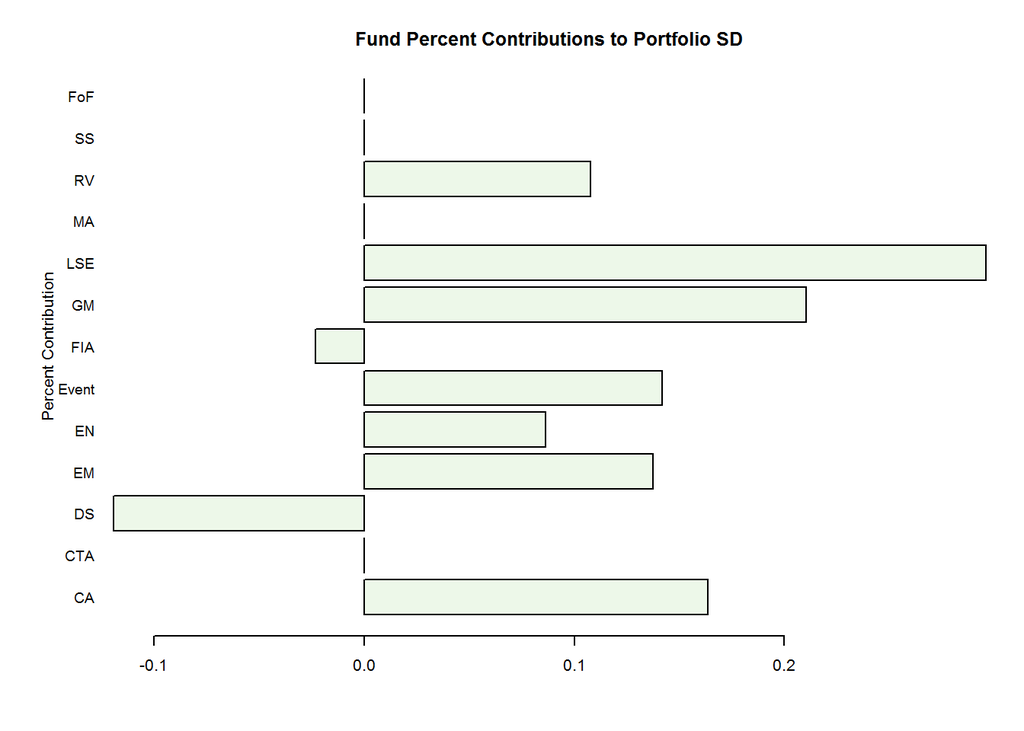

```r
# compute with sample covariance matrix (pairwise complete obvs)
cov.sample = cov(Managers.df[,manager.names],
                 use="pairwise.complete.obs")
port.sd.decomp.sample = portfolioSdDecomposition(w.vec, cov.sample)

names=as.vector(manager.names)
par(cex=0.65)
par(oma = c(1, 1, 1, 1))  # Outside margins: b, l, t, r
par(mar = c(4, 5, 2, 1))  # Sets plot margins
barplot(port.sd.decomp.sample$pcsd.p,
        main="Fund Percent Contributions to Portfolio SD",
        horiz  = TRUE,
#                    axisnames=FALSE,
                las    = 1,  # Orientation of axis labels,
cex.names=0.9,
names.arg=c("CA","CTA","DS","EM","EN","Event","FIA","GM","LSE","MA","RV","SS","FoF"),
        ylab="Percent Contribution",
        col=brewer.pal(6, "Greens"))
```

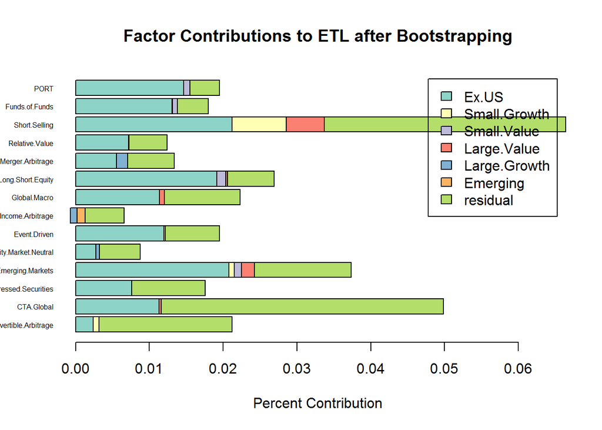

```r
# resample from historical factors
n.boot = 5000
# set random number sed
set.seed(123)
# reshuffled indices with replacement
bootIdx = sample(nrow(Managers.df),  n.boot, replace=TRUE)
# resampled factor data
factorDataBoot.mat = as.matrix(Managers.df[bootIdx, index.names])

# FMMC using normal distribution for residuals and alpha = 0
returns.boot = matrix(0, n.boot, length(manager.names))
resid.sim = matrix(0, n.boot, length(manager.names))
colnames(returns.boot) = colnames(resid.sim) = manager.names
for (i in manager.names) {
    returns.fm = factorDataBoot.mat%*%Betas[i, ]
    resid.sim[, i] = rnorm(n.boot,sd=sqrt(ResidVars[i]))
    returns.boot[, i] = returns.fm + resid.sim[, i]
}
# compute FMMC portfolio returns and factor model residuals
HP.boot = returns.boot%*%w.vec
resid.fm.p = resid.sim%*%w.vec


factor.es.decomp.list = list()
for (i in manager.names) {
    tmpData = cbind(returns.boot[, i], factorDataBoot.mat,
                    resid.sim[, i]/sqrt(ResidVars[i]))
    colnames(tmpData)[c(1,5)] = c(manager.names[i], "residual")
    factor.es.decomp.list[[i]] = factorModelFactorEsDecomposition(tmpData, Betas[i,],
                                                                  ResidVars[i], tail.prob=0.05)
}
# add portfolo retsults - need factor model residuals
tmpData = cbind(HP.boot, factorDataBoot.mat,
                resid.fm.p/sqrt(as.numeric(var.p.resid)))
colnames(tmpData)[c(1,5)] = c("PORT", "residual")
factor.es.decomp.list[["PORT"]] = factorModelFactorEsDecomposition(tmpData, beta.p,
                                                                   var.p.resid, tail.prob=0.05)

# stacked bar charts of percent contributions to SD
getCETL = function(x) {
    x$cES.fm
}
# report as positive number
cr.etl = sapply(factor.es.decomp.list, getCETL)
rownames(cr.etl) = c(index.names, "residual")
barplot(cr.etl, main="Factor Contributions to ETL after Bootstrapping",
       horiz  = TRUE,
#         legend=NULL,
        cex.names=0.5,
        las    = 1,
#         names.arg=c("CA","CTA","DS","EM","EN","Event","FIA","GM","LSE","MA","RV","SS","FoF"),
        xlab="Percent Contribution",
        legend=T,
        col=brewer.pal(12, "Set3"))
```